# Did COVID19 In-Hospital Fatality Change Since P1 Became Prevalent?

## Survival Analysis on SIVEP-Gripe Data

Adjust for the main factors that are thought to drive the risk of dying once hospitalized for COVID19:

- Age
- Comorbidities
- Hospital Load / Health Care Collapse

```python
import matplotlib.pyplot as plt
import matplotlib.ticker as ticker
import matplotlib.dates as mdates
import pandas as pd
import numpy as np
import seaborn as sns
import scipy.stats as st
from datetime import datetime, date, timedelta
from matplotlib.dates import DateFormatter
from lifelines import KaplanMeierFitter
from lifelines import NelsonAalenFitter
from lifelines import CoxPHFitter
from lifelines.datasets import load_rossi

pd.options.display.max_columns = 200
pd.options.display.max_rows = 100
```

### Pre Analysis Steps

#### SIVEP Loading, Parsing and Cleaning

Define SIVEP Release Define cutoff date of analysis (as an offset in weeks from latest SIVEP release)

```python
#### SIVEP RELEASE AND OFFSET PARAMETERS

sivep_release = pd.to_datetime('2021-04-05')

sivep_release_offset_weeks = 10 # Weeks

SIVEP_directory = '/Users/ricardo/Coding/COVID19/SIVEP_Gripe/data/'

####
```

```python
categoricos = ['CS_SEXO', 'CS_GESTANT', 'CS_RACA', 'CS_ETINIA', 'CS_ESCOL_N', 'CS_ZONA', 'CO_REGIONA', 'CO_MUN_NOT', 'CO_UNI_NOT', 'COD_IDADE', 'CO_PAIS', 'CO_RG_RESI', 'CO_MUN_RES', 'CO_RG_INTE', 'CO_MU_INTE', 'CO_LAB_IF', 'CO_LAB_PCR', 'CO_PS_VGM', 'SEM_NOT', 'SEM_PRI', 'SG_UF_NOT', 'SG_UF', 'SG_UF_INTE', 'TP_IDADE', 'TP_ANTIVIR', 'TP_AMOSTRA', 'TP_FLU_IF', 'TP_FLU_PCR', 'ID_REGIONA', 'ID_MUNICIP', 'ID_UNIDADE', 'ID_PAIS', 'ID_RG_RESI', 'ID_MN_RESI', 'ID_RG_INTE', 'ID_MN_INTE', 'HISTO_VGM', 'PAIS_VGM', 'CO_PS_VGM', 'SURTO_SG', 'NOSOCOMIAL', 'AVE_SUINO', 'FEBRE', 'TOSSE', 'GARGANTA', 'DISPNEIA', 'DESC_RESP', 'SATURACAO', 'DIARREIA', 'VOMITO', 'PUERPERA', 'CARDIOPATI', 'HEMATOLOGI', 'SIND_DOWN', 'HEPATICA', 'ASMA', 'DIABETES', 'NEUROLOGIC', 'PNEUMOPATI', 'IMUNODEPRE', 'RENAL', 'OBESIDADE', 'VACINA', 'MAE_VAC', 'M_AMAMENTA', 'ANTIVIRAL', 'HOSPITAL', 'UTI', 'SUPORT_VEN', 'RAIOX_RES', 'AMOSTRA', 'IF_RESUL', 'POS_IF_FLU', 'IF_VSR', 'IF_PARA1', 'IF_PARA2', 'IF_PARA3', 'IF_ADENO', 'LAB_IF', 'PCR_RESUL', 'POS_PCRFLU', 'PCR_FLUASU', 'PCR_FLUBLI', 'PCR_VSR', 'PCR_PARA1', 'PCR_PARA2', 'PCR_PARA3', 'PCR_PARA4', 'PCR_ADENO', 'PCR_METAP', 'PCR_BOCA', 'PCR_RINO', 'LAB_PCR', 'CLASSI_FIN', 'CRITERIO', 'EVOLUCAO', 'PCR_SARS2', 'PAC_COCBO', 'PAC_DSCBO']
numeros = ['#NU_NOTIFIC', 'NU_IDADE_N', 'NU_CEP', 'OBES_IMC' , 'REQUI_GAL']
textos = ['LO_PS_VGM','OUTRO_DES','MORB_DESC', 'OUT_ANTIV', 'RAIOX_OUT','OUT_AMOST', 'DS_IF_OUT', 'FLUASU_OUT','FLUBLI_OUT', 'POS_PCROUT', 'PCR_OUTRO', 'DS_PCR_OUT', 'CLASSI_OUT', 'OBSERVA']
date_columns = ['DT_NOTIFIC', 'DT_SIN_PRI', 'DT_NASC', 'DT_UT_DOSE', 'DT_VAC_MAE', 'DT_DOSEUNI', 'DT_1_DOSE', 'DT_2_DOSE', 'DT_ANTIVIR', 'DT_INTERNA', 'DT_ENTUTI', 'DT_SAIDUTI', 'DT_RAIOX', 'DT_COLETA', 'DT_PCR', 'DT_EVOLUCA', 'DT_ENCERRA', 'DT_DIGITA', 'DT_VGM', 'DT_RT_VGM']


datatypes = {}
for campo in textos:
    datatypes[campo] = 'str'

for campo in numeros:
    datatypes[campo] = 'float64'

for campo in categoricos:
    datatypes[campo] = 'category'

# Decomposes the sivep release date into day, month and year, rearranges it to be used in the filename
sivep_file_date = '-'.join([sivep_release.strftime('%d'),sivep_release.strftime('%m'),sivep_release.strftime('%Y')])

## Columns being used in this analysis
used_col_names = ['SG_UF_NOT','SG_UF_INTE','HOSPITAL','UTI','CLASSI_FIN','CRITERIO','PCR_SARS2','EVOLUCAO','DT_EVOLUCA', 'DT_INTERNA', 'DT_NASC', 'DT_SIN_PRI','SG_UF', 'ID_MN_INTE','ID_MN_RESI','DT_NOTIFIC','ID_MUNICIP',
                 'CARDIOPATI', 'SIND_DOWN', 'HEPATICA', 'ASMA', 'DIABETES', 'NEUROLOGIC', 'PNEUMOPATI', 'IMUNODEPRE', 'RENAL', 'OBESIDADE']
used_date_columns = ['DT_EVOLUCA', 'DT_INTERNA', 'DT_NASC', 'DT_SIN_PRI','DT_NOTIFIC']

df = pd.read_csv(f'{SIVEP_directory}/INFLUD-{sivep_file_date}.csv', sep=';', error_bad_lines=False, encoding='latin-1', usecols=used_col_names, dtype=datatypes)
df = df.append(pd.read_csv(f'{SIVEP_directory}/INFLUD21-{sivep_file_date}.csv', sep=';', error_bad_lines=False, encoding='latin-1', usecols=used_col_names, dtype=datatypes))


### Correctly parses date columns
for date_column in used_date_columns:
    df[date_column] = pd.to_datetime(df[date_column], format='%d/%m/%Y', errors='coerce') #Need to use coerce to allow for some NaTs
```

#### Preparing the Manaus data for Kaplan Meier curves

Notes:

- In a standard survival analysis with censored observations, once we censor a subject at a given time, we know for a fact he/she did not experience the event at that time (i.e.: that was the last known time that individual was alive).
- In SIVEP-Gripe we have right-censoring of outcomes, but that does not mean they are known to be alive. Thye could be either dead or alive, and thus these censored observations cannot be relied upon.
- I have chosen to determine a cutoff for analysis that is long enough in the past that it allows a reasonable time for outcomes field to be filled in. Any records with missing data are simply excluded. This might affect results. Steps:
1. Calculate the following intervals:
   - Onset of Symptoms to Hospital Admission
   - Onset of Symptoms to Death (or Hospital Discharge)
   - Hospital Admission to Death (or Hospital Discharge)
   - Age at notification
2. Create event columns with 0/1 responses for the following:
   - Death
   - Hospitalization
3. Exclude all records that were **notified** less than 10 weeks before the most recent SIVEP release
   - This should be enough to allow for sufficient time for hospital treatment to have happened and records updated.
4. Exclude all records with missing data for final outcome (EVOLUCAO and DT_EVOLUCA cannot be NaN)
5. Select only records that were **notified** in Amazonas (SG_UF_NOT == 'AM'). This should include both hospitalized and non hospitalized records, but non-hospitalized records will be excluded at the point of analysis.

```python
### STEP 1
### Calculate Intervals

## Time from Onset of Symptoms to Hospital Admission
df['Onset_to_Hosp'] = (df['DT_INTERNA'] - df['DT_SIN_PRI']).dt.days

## Time from Onset of Symptoms to Death or Discharge
df['Onset_to_Evolucao'] = (df['DT_EVOLUCA'] - df['DT_SIN_PRI']).dt.days

## Time from Hospital Admission to Death or Discharge
df['Hosp_to_Evolucao'] = (df['DT_EVOLUCA'] - df['DT_INTERNA']).dt.days

## Age at date of notification
df['Age'] = (df['DT_NOTIFIC'] - df['DT_NASC']).dt.days / 365.25 #This results in a datetime object representing age in years
df['Age'] = df['Age'].fillna(0).astype('int') # Converts from datetime to int
```

```python
### STEP 2
### Create the event columns

df.loc[(df['EVOLUCAO'] == '2'), 'Death'] = 1 # Creates the 'Death' column and assigns the value '1' to all records that died
df['Death'] = df['Death'].fillna(0) # By logic, all records that have missing data on this field did not have a clearly recorded death event, and thus should be filled with '0'

df.loc[(df['HOSPITAL'] == '1'), 'Hospitalization'] = 1 # Creates the 'Hospitalization' column and assigns the value '1' to all records that were indeed hospitalized
df['Hospitalization'] = df['Hospitalization'].fillna(0) # By logic, all records that have missing data on this field did not have a clearly recorded hospitalization event, and thus should be filled with '0'
```

```python
### STEP 3
### Keep only records notified up to sivep_release_offset_weeks before the latest SIVEP release
df_copy = df.copy(deep=True) #To be used later if needed
df = df[df['DT_NOTIFIC'] < (sivep_release - timedelta(weeks=sivep_release_offset_weeks))]
```

```python
### STEP 4
### Exclude all records with missing data for EVOLUCAO or DT_EVOLUCAO
df = df[df['DT_EVOLUCA'].notna()]
```

```python
### STEP 5
### Keep only records that were notified in Amazonas
df = df[df['SG_UF_NOT'] == 'AM']
```

#### Gathering Covariate Information

Add covariates:

- Age
- Hospital Load
- Excess Out of Hospital Deaths
- Diabetes
- Obesity
- Chronic Renal Disease
- Chronic Lung Disease
- Chronic Cardiovascular Disease
- Chronic Liver Disease
- Neurological Disease
- Imunodeficiency

#### Hospital Case Load

Determined from daily epidemiological bulletins released by Amazonas Health Department

```python
#### Load Hospital Case Load Information
hospital_load = pd.read_csv('../data/Manaus.HospitalCaseLoad.csv', parse_dates=['Date'], dayfirst=True, index_col='Date') # Sets the index as the date, which makes easier for merging later

## Corrects for missing days in the reports
hospital_load['Corrected_Hosp_Manaus_plus_Queue'].ffill(inplace=True) #There is one day of missing bulletins on 06 November 2020
```

#### Out of Hospital Deaths

Scraped from online Tableau published by Amazonas Health Department:  
https://public.tableau.com/views/MonitoramentoSepultamentos/Obtdomiclio

A baseline interwave period is defined between 01 July 2020 and 01 December 2020  
Mean and 95% Confidence Interval is calculated for this period

Excess Out of Hospital Deaths are calculated by two different methods:

- Conservatively: by subtracting the upper bound of the 95%CI from the total number of out of hospital deaths for that week
- Less conservatively: by subtracting the mean from the total number of out of hospital deaths for that week

```python
### Load Out of Hospital Deaths Information
home_deaths = pd.read_csv('../data/Manaus.OutOfHospitalDeaths-Daily.csv',parse_dates=['Date'], index_col='Date')

# Period of low disease activity to be used as a baseline for excess all-cause out of hospital deaths
# Looking at the plot I chose 01 July 2020 to 01 December 2020
quiet_period = home_deaths.loc[(home_deaths.index > '2020-07-01') & (home_deaths.index < '2020-12-01') , 'Total' ]

## Calculates the 95% CIs for this data
ci_OuH_deaths = st.norm.interval(0.95, loc=np.mean(quiet_period), scale=np.std(quiet_period))

## Calculates the excess weekly out of hospital deaths by subtracting the actual value from the upper boundary of the 99% CI
home_deaths['ExcessHomeDeaths_CI'] = home_deaths['Total'] - ci_OuH_deaths[1]
home_deaths['ExcessHomeDeaths_Mean'] = home_deaths['Total'] - quiet_period.mean()

home_deaths.loc[home_deaths['ExcessHomeDeaths_CI'] < 0, 'ExcessHomeDeaths_CI'] = 0 # Assigns all negative excess to zero. I don't see a reason why negative excess burials would have significance to COVID mortality
home_deaths.loc[home_deaths['ExcessHomeDeaths_Mean'] < 0, 'ExcessHomeDeaths_Mean'] = 0

print('Interwave Weekly Out of Hospital Deaths Mean: ',quiet_period.mean())
print('Interwave Weekly Out of Hospital Deaths Median: ',quiet_period.median())
print('Interwave Weekly Out of Hospital Deaths 95% CI: ',ci_OuH_deaths)
```

```
Interwave Weekly Out of Hospital Deaths Mean:  38.48684210526316
Interwave Weekly Out of Hospital Deaths Median:  40.0
Interwave Weekly Out of Hospital Deaths 95% CI:  (27.19635437613577, 49.77732983439054)
```

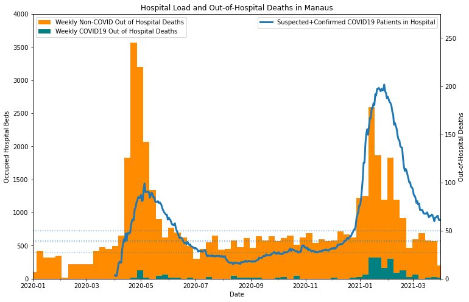

```python
######## Plot of hospital load and out of hospital deaths purely to visualize the confidence intervals to be used for excess out of hospital deaths
########

fig, ax = plt.subplots(figsize=(12,8))

ax2 = ax.twinx() # Creates second Y axis

# Plot total daily suspected+confirmed COVID19 hospital load for the city of Manaus on the LHS axis

hospital_load['Corrected_Hosp_Manaus_plus_Queue'].plot(ax=ax, # Main axis (LHS)
                                                  label='Suspected+Confirmed COVID19 Patients in Hospital',
                                                  linewidth=3
                                                  )


# Plot weekly Total Out of Hospital deaths in the city of Manaus using the RHS axis
ax2.bar(home_deaths['Total'].index,
        home_deaths['Total'].values,
        label='Weekly Non-COVID Out of Hospital Deaths',
        width=1,
        color='darkorange'
       )

# Creates a stacked barplot by plotting a small bar of COVID19-confirmed out of hospital deaths over the total bars
ax2.bar(home_deaths['COVID19'].index,
        home_deaths['COVID19'].values,
        label='Weekly COVID19 Out of Hospital Deaths',
        width=1,
        color='teal'
       )

#burials.groupby('DeathWeek')['2020_2021_pub_priv_burials_cremats'].sum().plot(ax=ax2)

#### Plots the 99% CI on Burials for the quite period

ax2.axhline(ci_OuH_deaths[0], alpha=0.5, linestyle=':') #Lower Bound
ax2.axhline(quiet_period.mean(), alpha=0.5, linestyle=':') #Mean
ax2.axhline(quiet_period.median(), alpha=0.5, linestyle=':') #Median
ax2.axhline(ci_OuH_deaths[1], alpha=0.5, linestyle=':') #Upper Bound

## Fixes the zorder of plots to make sure lineplot appears over the bars
ax2.set_zorder(1)
ax.set_zorder(2)
ax.patch.set_visible(False) # Turns the canvas of top plot invisible, so to be able to see the barplot underneath

ax.legend(loc='upper right')
ax2.legend(loc='upper left')

ax.set_ylabel('Occupied Hospital Beds')
ax.set_ylim([0,4000])

ax2.set_ylabel('Out-of-Hospital Deaths')
ax2.set_ylim([0,275])
ax2.set_xlim([pd.to_datetime('2020-01-01'),pd.to_datetime('2021-04-01')])

ax.set_title('Hospital Load and Out-of-Hospital Deaths in Manaus')

plt.show()
```

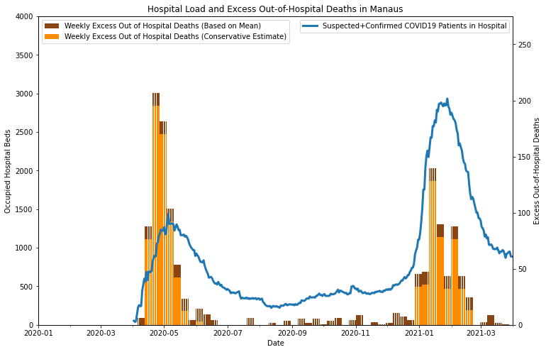

```python
###### Plot showing the two methods of calculating excess out of hospital deaths and hospital load
######

fig, ax = plt.subplots(figsize=(12,8))

ax2 = ax.twinx() # Creates second Y axis

# Plot total daily suspected+confirmed COVID19 hospital load for the city of Manaus on the LHS axis

hospital_load['Corrected_Hosp_Manaus_plus_Queue'].plot(ax=ax, # Main axis (LHS)
                                                  label='Suspected+Confirmed COVID19 Patients in Hospital',
                                                  linewidth=3
                                                  )


# Plot weekly EXCESS Out of Hospital deaths in the city of Manaus using the RHS axis
ax2.bar(home_deaths['ExcessHomeDeaths_Mean'].index,
        home_deaths['ExcessHomeDeaths_Mean'].values,
        label='Weekly Excess Out of Hospital Deaths (Based on Mean)',
        #width=1,
        color='saddlebrown'
       )

ax2.bar(home_deaths['ExcessHomeDeaths_CI'].index,
        home_deaths['ExcessHomeDeaths_CI'].values,
        label='Weekly Excess Out of Hospital Deaths (Conservative Estimate)',
        #width=1,
        color='darkorange'
       )


## Fixes the zorder of plots to make sure lineplot appears over the bars
ax2.set_zorder(1)
ax.set_zorder(2)
ax.patch.set_visible(False) # Turns the canvas of top plot invisible, so to be able to see the barplot underneath

ax.legend(loc='upper right')
ax2.legend(loc='upper left')

ax.set_ylabel('Occupied Hospital Beds')
ax.set_ylim([0,4000])

ax2.set_ylabel('Excess Out-of-Hospital Deaths')
ax2.set_ylim([0,275])
ax2.set_xlim([pd.to_datetime('2020-01-01'),pd.to_datetime('2021-04-01')])

ax.set_title('Hospital Load and Excess Out-of-Hospital Deaths in Manaus')

plt.show()
```

Note: Calculated excess out of hospital deaths by subtracting from mean seems to give more visually accurate results.  
i.e: there is a small tendency to increase out of hospital deaths as hospital load goes up late in the interwave period

```python
####### Merge tables together

#### Include hospital load information for each SIVEP record
## This is based on the hospital load on the day of hospital admission, which is arguably the most critical moment in care
df = df.merge(hospital_load, left_on='DT_INTERNA', right_index=True, how='left')

#### Include Excess Out of Hospital Deaths for each SIVEP record
df = df.merge(home_deaths[['ExcessHomeDeaths_CI','ExcessHomeDeaths_Mean']], left_on='DT_INTERNA', right_index=True, how='left')

df['ExcessHomeDeaths_CI'] = df['ExcessHomeDeaths_CI'].fillna(0) #Fills missing days or weeks with zeroes to avoid problems down the line
df['ExcessHomeDeaths_Mean'] = df['ExcessHomeDeaths_Mean'].fillna(0)
```

#### Atention: Lots of missing data on comorbidities

```python
#### Selects only for people who were HOSPITALIZED in MANAUS with a NON-COVID final classification
Manaus = df['ID_MN_INTE'] == 'MANAUS'
Hosp = df['HOSPITAL'] == '1' # Hospitalized patients only
SRAG_COVID = df['CLASSI_FIN'] == '5' # COVID19

## These are the comorbidities I am testing for
comorbidities = ['CARDIOPATI', 'SIND_DOWN', 'HEPATICA', 'ASMA', 'DIABETES', 'NEUROLOGIC', 'PNEUMOPATI', 'IMUNODEPRE', 'RENAL', 'OBESIDADE']

print('Total Manaus Hospitalised SRAG Records:',len(df[Manaus & Hosp]))
print('\nManaus Hospitalised SRAG Records missing comorbidites information:\n')
print((df.loc[Manaus & Hosp,comorbidities].isna().sum() + (df.loc[Manaus & Hosp, comorbidities] == '9').sum()) / len(df.loc[Manaus & Hosp, comorbidities]))

print('\nRemaining Manaus Hospitalised SRAG records available with full comorbidities data: ', len(df[Manaus & Hosp].dropna(subset=comorbidities)))
```

```
Total Manaus Hospitalised SRAG Records: 18889

Manaus Hospitalised SRAG Records missing comorbidites information:

CARDIOPATI    0.519509
SIND_DOWN     0.633120
HEPATICA      0.634020
ASMA          0.625020
DIABETES      0.541585
NEUROLOGIC    0.625761
PNEUMOPATI    0.628090
IMUNODEPRE    0.631955
RENAL         0.620890
OBESIDADE     0.631108
dtype: float64

Remaining Manaus Hospitalised SRAG records available with full comorbidities data:  6357
```

```python
#### Recodes comorbidities accurately for the model, which uses YES as 1 (integer) and NO as a zero.
## For now I am leaving the missing data to see what it spits out. More likely it will need to be imputated or removed
df[comorbidities] = df[comorbidities].apply(lambda x: x.cat.codes).replace({-1: np.NaN, 0:1, 1:0, 2: np.NaN})  # The cat.codes replaces categorigal variables with internal codes, and the replace bit remaps these codes to the values I want
```

#### When should we consider P1 prevalent?

I define any hospitalization on or after **01 December 2020** as being P1 affected, and none before that.

```python
#### Define Pre and Post P1 Periods Prevalence

P1_date = pd.to_datetime('2020-12-01')

# Sets the new column 'P1' as 1 if the patient was hospitalized during the P1 period or 0 if he'she was hospitalized before P1 was prevalent

df.loc[df['DT_INTERNA'] >= P1_date, 'P1'] = 1

df.loc[df['DT_INTERNA'] < P1_date, 'P1'] = 0
```

# Analysis Section

### Did NON-COVID SRAGs experience higher/faster in-hospital mortality due to COVID-related hospital overload in Manaus?

Use Cox Proportional Hazards to analyse covariates:

- Age
- Hospital COVID19 Load
- Excess Out of Hospital Deaths (a marker of hospital collapse)
- Comorbidities
- P1 Periods

##### Defines the critical Regression Analysis Function

Timeline is 28 days from hospital admission  
Event is in-hospital death

1. Runs univariate analysis on each covariate
2. Selects the ones that reach statistical significance (corrected by Bonferroni for the number of analyses done)
3. Runs multivariate Cox PH regression on these selected covariates
4. Plots the Hazard Ratios of covariates in multi regression

```python
def CoxAnalysis(data,duration_col,event_col,covariates,time, significance_level, formula = None, filters = None):

    global cph

    cph = CoxPHFitter() # Apparently this makes the variables global instead of local

    t = np.linspace(0, time, time+1) # define the timeline

    #### Prepare the dataset for Univariate analysis
    # Removes all records which have missing data for any of the fields analysed

    analysis_columns = [duration_col,event_col, *covariates] #unpacks covariates inside the list, essentially concatenating it

    data_uv = data.rename(columns={'Corrected_Hosp_Manaus_plus_Queue':'OccupiedBeds'}) \
                .dropna(subset=analysis_columns) # Critically removes records with missing data for field to be analysed


    # Initialy an empty summary dataframe
    summary = pd.DataFrame()

    # Run univariate analysis on each one of the covariates given
    for covariate in covariates:

        cph.fit(data_uv, duration_col=duration_col,event_col=event_col, formula=covariate, timeline=t)

        summary = summary.append(cph.summary) # append the results of this analysis to the Summary dataframe

    ## Bonferroni correction of significance value
    bonferroni = significance_level / len(covariates)

    # Creates new column 'UnivariateSignificance' and fills it with bonferroni-corrected threshold used on rows which passed statistical significance
    summary.loc[summary['p'] < bonferroni,'UnivariateSignificance'] = "<{:.3f}".format(round(bonferroni,3))

    ## Print Total Number of Records Analysed
    print('\nNumber of entries used in univariate analysis: ',len(data_uv))

    ## Print Table of Univariate Results
    print('\nUnivariate Regression Results\n')
    print(summary.to_string())

    #### MultiVariate Analysis with covariates that passed statistical significance

    covariates_passed_uv = summary[summary.UnivariateSignificance.notna()].index

    #### Prepare the dataset for Multivariate analysis
    # Removes all records which have missing data for any of the fields analysed

    analysis_columns = [duration_col,event_col, *covariates_passed_uv] #unpacks covariates inside the list, essentially concatenating it

    data_mv = data.rename(columns={'Corrected_Hosp_Manaus_plus_Queue':'OccupiedBeds'}) \
                .dropna(subset=analysis_columns) # Critically removes records with missing data for field to be analysed

    ## Creates the linear covariates formula to be passed for CoxPHFitter with only variables that passed univariate analysis

    if formula is None:

        formula = ' + '.join(covariates_passed_uv)

    else:

        formula = formula


    cph.fit(data_mv, duration_col=duration_col,event_col=event_col, formula=formula, timeline=t)

    ## Print Total Number of Records Analysed
    print('\nNumber of entries used in multivariate analysis: ',len(data_mv))

    ## Print Table of

    print('\nMultivariate Regression Results:\n')

    summary_mv = cph.summary
    summary_mv.loc[summary_mv['p'] < significance_level,'MultivariateSignificance'] = "<{:.3f}".format(significance_level)

    print(summary_mv.to_string())

    ## Print Hazard Ratio Plots

    print('\nHazard Ratios for Covariates: \n')
    cph.plot()
```

```python
covariates = ['CARDIOPATI',
 'SIND_DOWN',
 'HEPATICA',
 'ASMA',
 'DIABETES',
 'NEUROLOGIC',
 'PNEUMOPATI',
 'IMUNODEPRE',
 'RENAL',
 'OBESIDADE',
 'Age',
 'OccupiedBeds',
 'ExcessHomeDeaths_Mean',
 'P1',
]
```

### Manaus - Non-COVID SRAGs

```
Number of entries used in univariate analysis:  1505

Univariate Regression Results

                           coef  exp(coef)  se(coef)  coef lower 95%  coef upper 95%  exp(coef) lower 95%  exp(coef) upper 95%          z             p   -log2(p) UnivariateSignificance
covariate
CARDIOPATI             0.363077   1.437747  0.095489        0.175922        0.550233             1.192345             1.733656   3.802293  1.433632e-04  12.768038                 <0.004
SIND_DOWN              0.624887   1.868035  0.450051       -0.257197        1.506971             0.773216             4.513039   1.388481  1.649907e-01   2.599543                    NaN
HEPATICA              -0.260457   0.770699  0.381267       -1.007726        0.486813             0.365048             1.627122  -0.683135  4.945216e-01   1.015894                    NaN
ASMA                  -0.484026   0.616297  0.282091       -1.036914        0.068862             0.354547             1.071288  -1.715852  8.618906e-02   3.536352                    NaN
DIABETES               0.284180   1.328672  0.095401        0.097197        0.471163             1.102078             1.601856   2.978792  2.893875e-03   8.432782                 <0.004
NEUROLOGIC             0.160687   1.174318  0.150632       -0.134546        0.455921             0.874112             1.577625   1.066753  2.860833e-01   1.805493                    NaN
PNEUMOPATI             0.460688   1.585164  0.174130        0.119400        0.801975             1.126820             2.229942   2.645659  8.153186e-03   6.938420                    NaN
IMUNODEPRE            -0.574143   0.563187  0.235377       -1.035473       -0.112813             0.355058             0.893318  -2.439251  1.471773e-02   6.086301                    NaN
RENAL                  0.147828   1.159313  0.139214       -0.125027        0.420682             0.882473             1.523000   1.061874  2.882929e-01   1.794393                    NaN
OBESIDADE             -0.154798   0.856588  0.223884       -0.593602        0.284006             0.552334             1.328441  -0.691420  4.893014e-01   1.031205                    NaN
Age                    0.026187   1.026533  0.002527        0.021235        0.031140             1.021462             1.031630  10.363076  3.650309e-25  81.180184                 <0.004
OccupiedBeds           0.000678   1.000678  0.000085        0.000511        0.000844             1.000511             1.000845   7.956472  1.770136e-15  49.005061                 <0.004
ExcessHomeDeaths_Mean  0.005681   1.005697  0.000610        0.004484        0.006877             1.004494             1.006901   9.307069  1.314081e-20  66.044508                 <0.004
P1                    -0.332816   0.716902  0.167899       -0.661892       -0.003740             0.515875             0.996267  -1.982238  4.745265e-02   4.397367                    NaN

Number of entries used in multivariate analysis:  1808

Multivariate Regression Results:

                                        coef  exp(coef)  se(coef)  coef lower 95%  coef upper 95%  exp(coef) lower 95%  exp(coef) upper 95%          z             p   -log2(p) MultivariateSignificance
covariate
Age                                 0.025702   1.026035  0.002400        0.020997        0.030407             1.021219             1.030874  10.707306  9.405921e-27  86.458489                   <0.050
CARDIOPATI                          0.037032   1.037727  0.086114       -0.131749        0.205813             0.876561             1.228524   0.430037  6.671688e-01   0.583876                      NaN
DIABETES                            0.142340   1.152969  0.083465       -0.021248        0.305928             0.978976             1.357884   1.705393  8.812109e-02   3.504369                      NaN
ExcessHomeDeaths_Mean               0.011429   1.011495  0.001944        0.007619        0.015239             1.007648             1.015356   5.879624  4.111993e-09  27.857515                   <0.050
OccupiedBeds                        0.000875   1.000875  0.000155        0.000571        0.001178             1.000572             1.001179   5.652183  1.584227e-08  25.911646                   <0.050
ExcessHomeDeaths_Mean:OccupiedBeds -0.000007   0.999993  0.000002       -0.000011       -0.000003             0.999989             0.999997  -3.663132  2.491505e-04  11.970695                   <0.050

Hazard Ratios for Covariates:
```

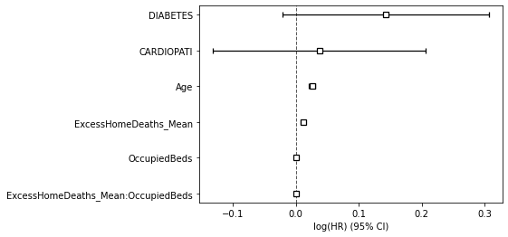

```python
CoxAnalysis(df[Manaus & Hosp & ~SRAG_COVID], 'Hosp_to_Evolucao','Death', covariates, 28, 0.05,formula="Age + CARDIOPATI + DIABETES + OccupiedBeds * ExcessHomeDeaths_Mean")
```

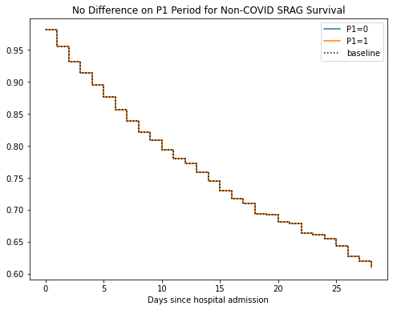

```python
cph.plot_partial_effects_on_outcome(covariates='P1', values=[0,1], title='No Difference on P1 Period for Non-COVID SRAG Survival',figsize=(8,6))
plt.xlabel('Days since hospital admission')
plt.show()
```

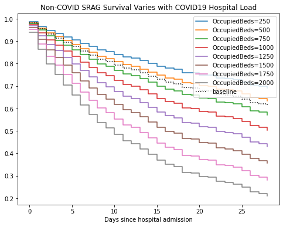

```python
cph.plot_partial_effects_on_outcome(covariates='OccupiedBeds', values=[250,500,750,1000,1250,1500,1750,2000], title='Non-COVID SRAG Survival Varies with COVID19 Hospital Load', figsize=(8,6))
plt.xlabel('Days since hospital admission')
plt.legend(loc='upper right')
plt.show()
```

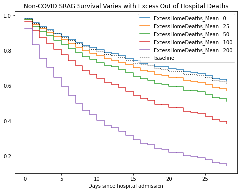

```python
cph.plot_partial_effects_on_outcome(covariates='ExcessHomeDeaths_Mean', values=[0,25,50,100,200], title='Non-COVID SRAG Survival Varies with Excess Out of Hospital Deaths', figsize=(8,6))
plt.xlabel('Days since hospital admission')
plt.legend(loc='upper right')
plt.show()
```

### Did COVID SRAGs experience higher/faster in-hospital mortality after P1 became prevalent in Manaus?

Use Cox Proportional Hazards to analyse covariates:

- Age
- Hospital COVID19 Load
- Excess Out of Hospital Deaths (a marker of hospital collapse)
- Comorbidities
- P1 Periods

```
Number of entries used in univariate analysis:  4416

Univariate Regression Results

                           coef  exp(coef)  se(coef)  coef lower 95%  coef upper 95%  exp(coef) lower 95%  exp(coef) upper 95%          z             p    -log2(p) UnivariateSignificance
covariate
CARDIOPATI             0.152465   1.164702  0.043221        0.067754        0.237176             1.070102             1.267665   3.527595  4.193537e-04   11.219545                 <0.004
SIND_DOWN              0.193192   1.213115  0.251018       -0.298794        0.685177             0.741712             1.984123   0.769634  4.415173e-01    1.179458                    NaN
HEPATICA               0.183826   1.201806  0.157725       -0.125309        0.492961             0.882224             1.637156   1.165485  2.438228e-01    2.036095                    NaN
ASMA                  -0.355393   0.700898  0.129947       -0.610084       -0.100701             0.543305             0.904203  -2.734904  6.239853e-03    7.324272                    NaN
DIABETES               0.137056   1.146892  0.043248        0.052292        0.221819             1.053683             1.248346   3.169097  1.529135e-03    9.353068                 <0.004
NEUROLOGIC            -0.129085   0.878899  0.090702       -0.306858        0.048688             0.735755             1.049893  -1.423173  1.546860e-01    2.692586                    NaN
PNEUMOPATI             0.143401   1.154192  0.087818       -0.028718        0.315520             0.971690             1.370972   1.632940  1.024817e-01    3.286562                    NaN
IMUNODEPRE            -0.415677   0.659894  0.113673       -0.638471       -0.192882             0.528099             0.824579  -3.656779  2.554041e-04   11.934931                 <0.004
RENAL                  0.052361   1.053756  0.071820       -0.088403        0.193126             0.915392             1.213035   0.729061  4.659646e-01    1.101708                    NaN
OBESIDADE              0.003389   1.003394  0.069849       -0.133512        0.140290             0.875017             1.150607   0.048515  9.613056e-01    0.056933                    NaN
Age                    0.021949   1.022192  0.001415        0.019175        0.024723             1.019360             1.025031  15.509365  2.998273e-54  177.799986                 <0.004
OccupiedBeds           0.000271   1.000271  0.000028        0.000215        0.000326             1.000215             1.000326   9.600341  7.968001e-22   70.088200                 <0.004
ExcessHomeDeaths_Mean  0.004228   1.004237  0.000305        0.003630        0.004826             1.003637             1.004837  13.864764  1.035657e-43  142.792362                 <0.004
P1                     0.334446   1.397165  0.046622        0.243068        0.425823             1.275155             1.530850   7.173529  7.308877e-13   40.315415                 <0.004

Number of entries used in multivariate analysis:  4816

Multivariate Regression Results:

                           coef  exp(coef)  se(coef)  coef lower 95%  coef upper 95%  exp(coef) lower 95%  exp(coef) upper 95%          z             p    -log2(p) MultivariateSignificance
covariate
Age                    0.022933   1.023198  0.001411        0.020168        0.025698             1.020373             1.026031  16.256790  1.999427e-59  194.994171                   <0.050
CARDIOPATI             0.039090   1.039864  0.042084       -0.043393        0.121574             0.957535             1.129273   0.928858  3.529627e-01    1.502412                      NaN
DIABETES               0.090587   1.094817  0.041206        0.009824        0.171350             1.009873             1.186907   2.198380  2.792203e-02    5.162452                   <0.050
ExcessHomeDeaths_Mean  0.004844   1.004856  0.000379        0.004102        0.005587             1.004111             1.005602  12.790940  1.842314e-37  122.029820                   <0.050
IMUNODEPRE            -0.151278   0.859609  0.107186       -0.361358        0.058802             0.696729             1.060566  -1.411363  1.581377e-01    2.660747                      NaN
OccupiedBeds          -0.000061   0.999939  0.000044       -0.000148        0.000025             0.999852             1.000025  -1.384210  1.662941e-01    2.588191                      NaN
P1                     0.387801   1.473737  0.060851        0.268534        0.507068             1.308046             1.660415   6.372915  1.854684e-10   32.328108                   <0.050

Hazard Ratios for Covariates:
```

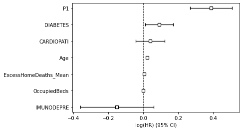

```python
CoxAnalysis(df[Manaus & Hosp & SRAG_COVID], 'Hosp_to_Evolucao','Death', covariates, 28, 0.05)
```

Oddly Hospital Load does not seem to be independetly correlated with COVID Survival. This doesn't seem right, and it could be due to the interaction of hospital load with other factors, especially Out of Hospital Deaths Technically out of hospital deaths are just an extension of very high hospital loads.

Repeat the multivariate analysis with an interaction factor between hospital load and excess of out of hospital deaths

```
Number of entries used in univariate analysis:  4416

Univariate Regression Results

                           coef  exp(coef)  se(coef)  coef lower 95%  coef upper 95%  exp(coef) lower 95%  exp(coef) upper 95%          z             p    -log2(p) UnivariateSignificance
covariate
CARDIOPATI             0.152465   1.164702  0.043221        0.067754        0.237176             1.070102             1.267665   3.527595  4.193537e-04   11.219545                 <0.004
SIND_DOWN              0.193192   1.213115  0.251018       -0.298794        0.685177             0.741712             1.984123   0.769634  4.415173e-01    1.179458                    NaN
HEPATICA               0.183826   1.201806  0.157725       -0.125309        0.492961             0.882224             1.637156   1.165485  2.438228e-01    2.036095                    NaN
ASMA                  -0.355393   0.700898  0.129947       -0.610084       -0.100701             0.543305             0.904203  -2.734904  6.239853e-03    7.324272                    NaN
DIABETES               0.137056   1.146892  0.043248        0.052292        0.221819             1.053683             1.248346   3.169097  1.529135e-03    9.353068                 <0.004
NEUROLOGIC            -0.129085   0.878899  0.090702       -0.306858        0.048688             0.735755             1.049893  -1.423173  1.546860e-01    2.692586                    NaN
PNEUMOPATI             0.143401   1.154192  0.087818       -0.028718        0.315520             0.971690             1.370972   1.632940  1.024817e-01    3.286562                    NaN
IMUNODEPRE            -0.415677   0.659894  0.113673       -0.638471       -0.192882             0.528099             0.824579  -3.656779  2.554041e-04   11.934931                 <0.004
RENAL                  0.052361   1.053756  0.071820       -0.088403        0.193126             0.915392             1.213035   0.729061  4.659646e-01    1.101708                    NaN
OBESIDADE              0.003389   1.003394  0.069849       -0.133512        0.140290             0.875017             1.150607   0.048515  9.613056e-01    0.056933                    NaN
Age                    0.021949   1.022192  0.001415        0.019175        0.024723             1.019360             1.025031  15.509365  2.998273e-54  177.799986                 <0.004
OccupiedBeds           0.000271   1.000271  0.000028        0.000215        0.000326             1.000215             1.000326   9.600341  7.968001e-22   70.088200                 <0.004
ExcessHomeDeaths_Mean  0.004228   1.004237  0.000305        0.003630        0.004826             1.003637             1.004837  13.864764  1.035657e-43  142.792362                 <0.004
P1                     0.334446   1.397165  0.046622        0.243068        0.425823             1.275155             1.530850   7.173529  7.308877e-13   40.315415                 <0.004

Number of entries used in multivariate analysis:  4816

Multivariate Regression Results:

                                        coef  exp(coef)      se(coef)  coef lower 95%  coef upper 95%  exp(coef) lower 95%  exp(coef) upper 95%          z             p    -log2(p) MultivariateSignificance
covariate
Age                                 0.023424   1.023701  1.419770e-03        0.020641        0.026207             1.020856             1.026553  16.498485  3.762153e-61  200.726055                   <0.050
CARDIOPATI                          0.039918   1.040726  4.207605e-02       -0.042549        0.122386             0.958343             1.130190   0.948716  3.427651e-01    1.544708                      NaN
DIABETES                            0.091031   1.095303  4.120602e-02        0.010268        0.171793             1.010321             1.187432   2.209159  2.716358e-02    5.202183                   <0.050
ExcessHomeDeaths_Mean               0.008214   1.008248  7.385841e-04        0.006766        0.009662             1.006789             1.009708  11.121262  9.886363e-29   93.030475                   <0.050
IMUNODEPRE                         -0.150141   0.860586  1.072242e-01       -0.360297        0.060014             0.697469             1.061851  -1.400258  1.614362e-01    2.630964                      NaN
OccupiedBeds                        0.000216   1.000217  6.724596e-05        0.000085        0.000348             1.000085             1.000348   3.219402  1.284583e-03    9.604484                   <0.050
P1                                  0.402926   1.496196  5.980393e-02        0.285712        0.520139             1.330710             1.682262   6.737447  1.611932e-11   35.852418                   <0.050
ExcessHomeDeaths_Mean:OccupiedBeds -0.000004   0.999996  6.742942e-07       -0.000005       -0.000002             0.999995             0.999998  -5.282443  1.274726e-07   22.903309                   <0.050

Hazard Ratios for Covariates:
```

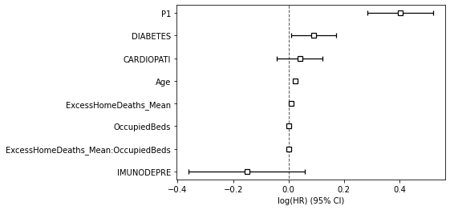

```python
CoxAnalysis(df[Manaus & Hosp & SRAG_COVID], 'Hosp_to_Evolucao','Death', covariates, 28, 0.05, formula="Age + CARDIOPATI + DIABETES + IMUNODEPRE + P1 + OccupiedBeds * ExcessHomeDeaths_Mean")
```

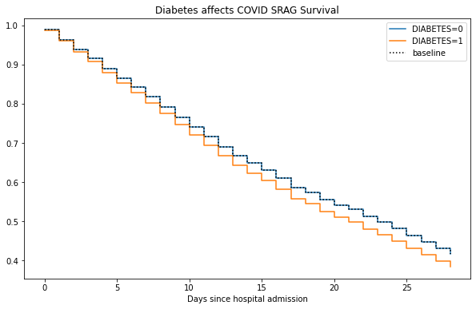

```python
cph.plot_partial_effects_on_outcome(covariates='DIABETES', values=[0,1], title='Diabetes affects COVID SRAG Survival',figsize=(10,6))
plt.xlabel('Days since hospital admission')
plt.show()
```

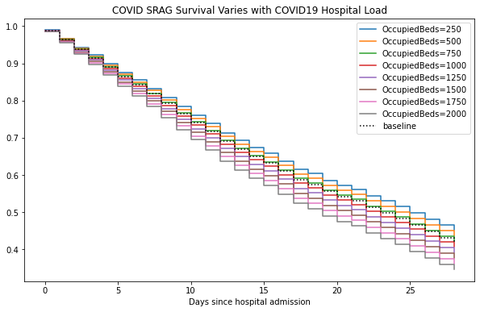

```python
cph.plot_partial_effects_on_outcome(covariates='OccupiedBeds', values=[250,500,750,1000,1250,1500,1750,2000], title='COVID SRAG Survival Varies with COVID19 Hospital Load', figsize=(10,6))
plt.xlabel('Days since hospital admission')
plt.legend(loc='upper right')
plt.show()
```

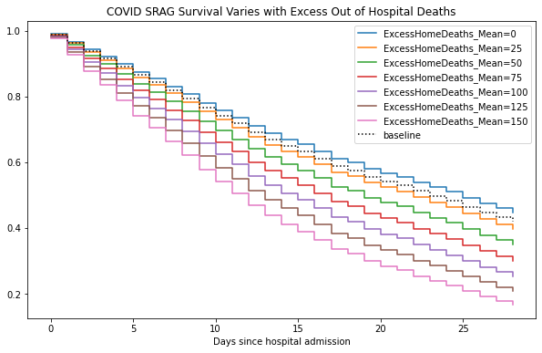

```python
cph.plot_partial_effects_on_outcome(covariates='ExcessHomeDeaths_Mean', values=[0,25,50,75,100,125,150], title='COVID SRAG Survival Varies with Excess Out of Hospital Deaths', figsize=(10,6))
plt.xlabel('Days since hospital admission')
plt.legend(loc='upper right')
plt.show()
```

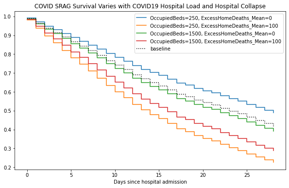

```python
cph.plot_partial_effects_on_outcome(covariates=['OccupiedBeds','ExcessHomeDeaths_Mean'], values=[[250,0],[250,100],[1500,0],[1500,100]], title='COVID SRAG Survival Varies with COVID19 Hospital Load and Hospital Collapse', figsize=(10,6))
plt.xlabel('Days since hospital admission')
plt.legend(loc='upper right')
plt.show()
```

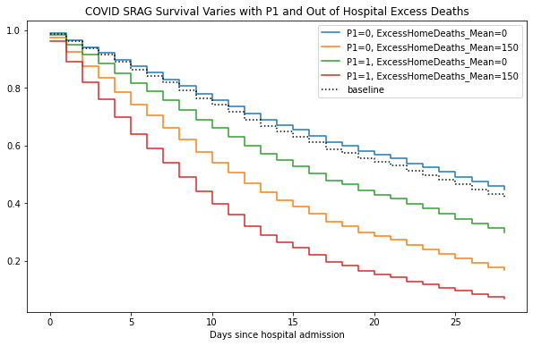

```python
cph.plot_partial_effects_on_outcome(covariates=['P1','ExcessHomeDeaths_Mean'], values=[[0,0],[0,150],[1,0],[1,150]], title='COVID SRAG Survival Varies with P1 and Out of Hospital Excess Deaths', figsize=(10,6))
plt.xlabel('Days since hospital admission')
plt.legend(loc='upper right')
plt.show()
```

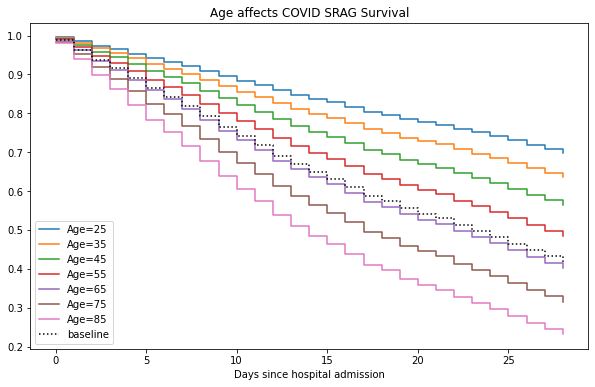

```python
cph.plot_partial_effects_on_outcome(covariates='Age', values=[25,35,45,55,65,75,85], title='Age affects COVID SRAG Survival',figsize=(10,6))
plt.xlabel('Days since hospital admission')
plt.show()
```

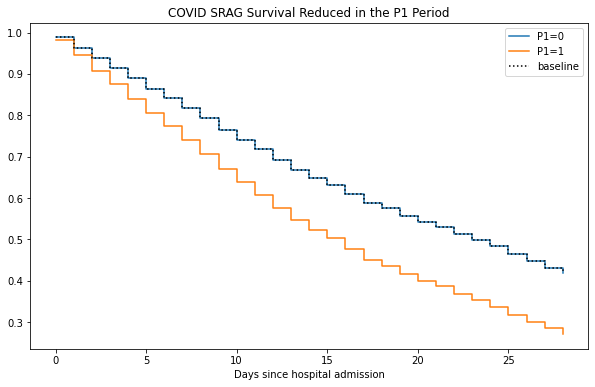

```python
cph.plot_partial_effects_on_outcome(covariates='P1', values=[0,1], title='COVID SRAG Survival Reduced in the P1 Period',figsize=(10,6))
plt.xlabel('Days since hospital admission')
plt.show()
```

## Do these results show similar results in Rio Grande do Sul state?

```python
### STEP 3
### Keep only records notified up to sivep_release_offset_weeks before the latest SIVEP release
df_gaucho = df_copy.copy(deep=True) #To be used later if needed
```

```python
#### Import Hospital Data for RS
gaucho = pd.read_csv(f'{SIVEP_directory}RS_HospitalData_08042021.csv')
gaucho.Date_Updated = pd.to_datetime(gaucho.Date_Updated)

## These are the columns which will be added up to calculate how many patients in total are receiving hospital treatment for suspected or confirmed COVID
ColumnsHospitalizations = ['Suspected_Adult_ICU',
       'Confirmed_Adult_ICU',

       'Suspected_Ped_ICU',
       'Confirmed_Ped_ICU',

       'Suspected_Adult_Ward',
       'Confirmed_Adult_Ward',

       'Suspected_Ped_Ward',
       'Confirmed_Ped_Ward']

## Originally the imported CSV has one line per Hospital, and each has to be updated on a daily basis.
# This groups all updates for a given date and sums them by column, getting the total for each category
# and then sums across the line, getting a grande total of beds occupied.
gaucho_resampled = gaucho.resample('D', on='Date_Updated')[ColumnsHospitalizations].sum().sum(axis=1)
```

#### When should we consider P1 prevalent in RS?

```python
#### Define Pre and Post P1 Periods Prevalence

P1_date = pd.to_datetime('2021-02-01')

# Sets the new column 'P1' as 1 if the patient was hospitalized during the P1 period or 0 if he'she was hospitalized before P1 was prevalent

df_gaucho.loc[df_gaucho['DT_INTERNA'] >= P1_date, 'P1'] = 1

df_gaucho.loc[df_gaucho['DT_INTERNA'] < P1_date, 'P1'] = 0
```

Cut off for SIVEP hospital admission needs to be more recent, as the second wave in RS is still ongoing.  
Defined cutoff as 4 weeks later than the Manaus cutoff Moving this data any further forward increase substantially the number of entries for which there are no updates on outcomes,  
and this is not the type of censoring that survival analysis typically deals with.

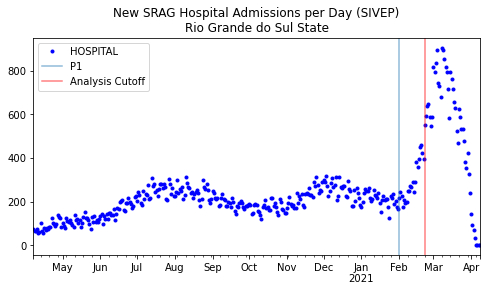

```python
RS_sivep_analysis_cutoff = sivep_release - timedelta(weeks=sivep_release_offset_weeks - 4)

ax = plt.subplot(111)
df_gaucho[df_gaucho.SG_UF_INTE == 'RS'].resample('D', on='DT_INTERNA')['HOSPITAL'].count().to_frame().reindex(pd.date_range(gaucho_resampled.index.min(),gaucho_resampled.index.max())).plot(style='b.', ax=ax, figsize=(8,4))
ax.set_title('New SRAG Hospital Admissions per Day (SIVEP)\nRio Grande do Sul State')
ax.axvline(P1_date, alpha=0.5, label='P1')
ax.axvline(RS_sivep_analysis_cutoff, alpha=0.5, color='red', label='Analysis Cutoff')
ax.legend().set_visible(True)
plt.show()
```

```python
df_gaucho = df_gaucho[df_gaucho['DT_NOTIFIC'] < RS_sivep_analysis_cutoff]
```

Exclude all records with missing data for outcome

```python
### STEP 4
### Exclude all records with missing data for EVOLUCAO or DT_EVOLUCAO
df_gaucho = df_gaucho[df_gaucho['DT_EVOLUCA'].notna()]
```

```python
### STEP 5
### Keep only records that were hospitalised in Rio Grande do Sul state
df_gaucho = df_gaucho[df_gaucho['SG_UF_INTE'] == 'RS']
```

```python
#### Recodes comorbidities accurately for the model, which uses YES as 1 (integer) and NO as a zero.
## For now I am leaving the missing data to see what it spits out. More likely it will need to be imputated or removed
df_gaucho[comorbidities] = df_gaucho[comorbidities].apply(lambda x: x.cat.codes).replace({-1: np.NaN, 0:1, 1:0, 2: np.NaN})  # The cat.codes replaces categorigal variables with internal codes, and the replace bit remaps these codes to the values I want
```

```python
#### Selects only for people who were HOSPITALIZED in Rio Grande do Sul
RS = df_gaucho['SG_UF_INTE'] == 'RS'
Hosp = df_gaucho['HOSPITAL'] == '1' # Hospitalized patients only

## These are the comorbidities I am testing for
comorbidities = ['CARDIOPATI', 'SIND_DOWN', 'HEPATICA', 'ASMA', 'DIABETES', 'NEUROLOGIC', 'PNEUMOPATI', 'IMUNODEPRE', 'RENAL', 'OBESIDADE']

print('Total Rio Grande do Sul Hospitalised SRAG Records:',len(df_gaucho[RS & Hosp]))
print('\nRio Grande do Sul Hospitalised SRAG Records missing comorbidites information:\n')
print((df_gaucho.loc[RS & Hosp,comorbidities].isna().sum() + (df_gaucho.loc[RS & Hosp, comorbidities] == '9').sum()) / len(df_gaucho.loc[RS & Hosp, comorbidities]))

print('\nRemaining Rio Grande do Sul Hospitalised SRAG records available with full comorbidities data: ', len(df_gaucho[RS & Hosp].dropna(subset=comorbidities)))
```

```
Total Rio Grande do Sul Hospitalised SRAG Records: 59907

Rio Grande do Sul Hospitalised SRAG Records missing comorbidites information:

CARDIOPATI    0.329761
SIND_DOWN     0.420869
HEPATICA      0.422939
ASMA          0.414042
DIABETES      0.359123
NEUROLOGIC    0.407565
PNEUMOPATI    0.405362
IMUNODEPRE    0.415861
RENAL         0.415895
OBESIDADE     0.412189
dtype: float64

Remaining Rio Grande do Sul Hospitalised SRAG records available with full comorbidities data:  32193
```

```python
#### Include hospital load information for each SIVEP record
## This is based on the hospital load on the day of hospital admission, which is arguably the most critical moment in care
df_gaucho = df_gaucho.merge(gaucho_resampled.to_frame('OccupiedBeds'), left_on='DT_INTERNA', right_index=True, how='left')
```

```python
SRAG_COVID = df_gaucho['CLASSI_FIN'] == '5'
NOT_COVID = df_gaucho['CLASSI_FIN'].isin(['1','2','3','4'])

covariates_rs = ['CARDIOPATI',
 'SIND_DOWN',
 'HEPATICA',
 'ASMA',
 'DIABETES',
 'NEUROLOGIC',
 'PNEUMOPATI',
 'IMUNODEPRE',
 'RENAL',
 'OBESIDADE',
 'Age',
 'OccupiedBeds','P1']
```

### Did NON-COVID SRAGs experience higher/faster in-hospital mortality in the P1 period in Rio Grande do Sul?

Use Cox Proportional Hazards to analyse covariates:

- Age
- Hospital COVID19 Load (state-wide)
- Comorbidities
- P1 Periods

```
Number of entries used in univariate analysis:  11833

Univariate Regression Results

                  coef  exp(coef)  se(coef)  coef lower 95%  coef upper 95%  exp(coef) lower 95%  exp(coef) upper 95%          z             p    -log2(p) UnivariateSignificance
covariate
CARDIOPATI    0.091950   1.096311  0.037164        0.019110        0.164791             1.019294             1.179146   2.474181  1.335419e-02    6.226564                    NaN
SIND_DOWN    -0.244984   0.782717  0.224482       -0.684960        0.194992             0.504110             1.215301  -1.091331  2.751271e-01    1.861830                    NaN
HEPATICA      0.253548   1.288590  0.091849        0.073527        0.433570             1.076298             1.542755   2.760480  5.771647e-03    7.436801                    NaN
ASMA         -0.632409   0.531310  0.086450       -0.801848       -0.462969             0.448499             0.629412  -7.315289  2.568284e-13   41.824261                 <0.004
DIABETES      0.053292   1.054737  0.040701       -0.026481        0.133064             0.973867             1.142324   1.309349  1.904162e-01    2.392772                    NaN
NEUROLOGIC    0.157173   1.170198  0.047374        0.064323        0.250024             1.066436             1.284056   3.317735  9.075065e-04   10.105804                 <0.004
PNEUMOPATI   -0.202044   0.817059  0.049829       -0.299707       -0.104381             0.741036             0.900882  -4.054766  5.018447e-05   14.282399                 <0.004
IMUNODEPRE    0.063217   1.065258  0.055193       -0.044958        0.171393             0.956037             1.186957   1.145393  2.520462e-01    1.988240                    NaN
RENAL         0.167941   1.182867  0.060493        0.049377        0.286505             1.050616             1.331765   2.776206  5.499738e-03    7.506421                    NaN
OBESIDADE    -0.154079   0.857204  0.076216       -0.303461       -0.004698             0.738259             0.995313  -2.021601  4.321756e-02    4.532239                    NaN
Age           0.019411   1.019601  0.001067        0.017321        0.021502             1.017472             1.021735  18.198405  5.313288e-74  243.413074                 <0.004
OccupiedBeds  0.000007   1.000007  0.000024       -0.000039        0.000054             0.999961             1.000054   0.316257  7.518074e-01    0.411565                    NaN
P1            0.284784   1.329475  0.104985        0.079018        0.490550             1.082223             1.633215   2.712621  6.675339e-03    7.226943                    NaN

Number of entries used in multivariate analysis:  13348

Multivariate Regression Results:

                coef  exp(coef)  se(coef)  coef lower 95%  coef upper 95%  exp(coef) lower 95%  exp(coef) upper 95%          z             p    -log2(p) MultivariateSignificance
covariate
ASMA       -0.399735   0.670498  0.079800       -0.556140       -0.243331             0.573418             0.784012  -5.009230  5.464829e-07   20.803320                   <0.050
Age         0.019061   1.019244  0.000986        0.017128        0.020993             1.017276             1.021215  19.330744  2.961195e-83  274.153852                   <0.050
NEUROLOGIC  0.089721   1.093869  0.044727        0.002058        0.177385             1.002060             1.194090   2.005970  4.485943e-02    4.478445                   <0.050
PNEUMOPATI -0.161487   0.850878  0.045886       -0.251422       -0.071552             0.777694             0.930948  -3.519289  4.327045e-04   11.174330                   <0.050

Hazard Ratios for Covariates:
```

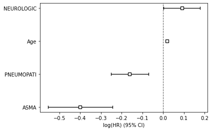

```python
CoxAnalysis(df_gaucho[Hosp & NOT_COVID], 'Hosp_to_Evolucao','Death', covariates_rs, 28, 0.05)
```

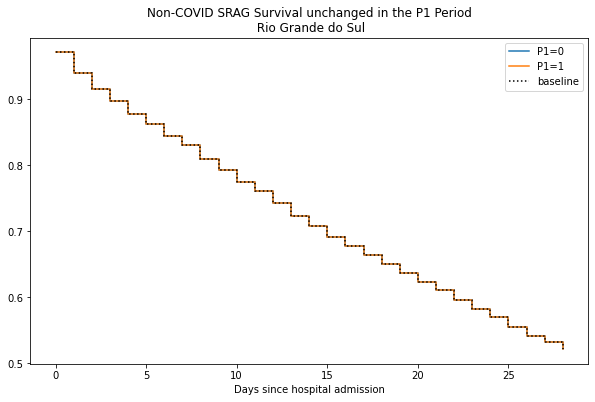

```python
cph.plot_partial_effects_on_outcome(covariates='P1', values=[0,1], title='Non-COVID SRAG Survival unchanged in the P1 Period\n Rio Grande do Sul',figsize=(10,6))
plt.xlabel('Days since hospital admission')
plt.show()
```

### Did COVID SRAGs experience higher/faster in-hospital mortality in the P1 period in Rio Grande do Sul?

Use Cox Proportional Hazards to analyse covariates:

- Age
- Hospital COVID19 Load (state-wide)
- Comorbidities
- P1 Periods

```
Number of entries used in univariate analysis:  19227

Univariate Regression Results

                  coef  exp(coef)  se(coef)  coef lower 95%  coef upper 95%  exp(coef) lower 95%  exp(coef) upper 95%          z              p    -log2(p) UnivariateSignificance
covariate
CARDIOPATI    0.152979   1.165301  0.024020        0.105902        0.200057             1.111712             1.221472   6.368933   1.903474e-10   32.290646                 <0.004
SIND_DOWN     0.046532   1.047631  0.192832       -0.331411        0.424475             0.717910             1.528787   0.241307   8.093168e-01    0.305224                    NaN
HEPATICA      0.259613   1.296428  0.069907        0.122598        0.396627             1.130430             1.486801   3.713707   2.042453e-04   12.257409                 <0.004
ASMA         -0.294414   0.744968  0.054830       -0.401879       -0.186949             0.669062             0.829486  -5.369551   7.893291e-08   23.594798                 <0.004
DIABETES      0.063989   1.066080  0.024209        0.016539        0.111438             1.016677             1.117885   2.643133   8.214271e-03    6.927652                    NaN
NEUROLOGIC    0.391315   1.478925  0.032663        0.327297        0.455333             1.387214             1.576699  11.980450   4.498729e-33  107.454110                 <0.004
PNEUMOPATI    0.181882   1.199472  0.034672        0.113926        0.249837             1.120669             1.283817   5.245783   1.556201e-07   22.615468                 <0.004
IMUNODEPRE    0.038799   1.039562  0.043374       -0.046212        0.123810             0.954840             1.131801   0.894537   3.710348e-01    1.430373                    NaN
RENAL         0.159848   1.173332  0.040699        0.080079        0.239616             1.083373             1.270762   3.927568   8.580926e-05   13.508507                 <0.004
OBESIDADE    -0.214591   0.806872  0.033119       -0.279503       -0.149678             0.756160             0.860985  -6.479362   9.211134e-11   33.337830                 <0.004
Age           0.030295   1.030759  0.000896        0.028540        0.032050             1.028951             1.032569  33.826414  8.067145e-251  830.791894                 <0.004
OccupiedBeds  0.000223   1.000223  0.000020        0.000183        0.000262             1.000183             1.000262  10.920662   9.182423e-28   89.815112                 <0.004
P1            0.457315   1.579826  0.041064        0.376831        0.537798             1.457659             1.712232  11.136754   8.309336e-29   93.281182                 <0.004

Number of entries used in multivariate analysis:  19407

Multivariate Regression Results:

                  coef  exp(coef)  se(coef)  coef lower 95%  coef upper 95%  exp(coef) lower 95%  exp(coef) upper 95%          z              p    -log2(p) MultivariateSignificance
covariate
ASMA         -0.177492   0.837368  0.054717       -0.284735       -0.070248             0.752214             0.932162  -3.243810   1.179424e-03    9.727702                   <0.050
Age           0.029962   1.030415  0.000957        0.028086        0.031837             1.028484             1.032349  31.309034  3.515838e-215  712.400672                   <0.050
CARDIOPATI   -0.032976   0.967562  0.024378       -0.080755        0.014803             0.922420             1.014913  -1.352718   1.761458e-01    2.505158                      NaN
HEPATICA      0.367326   1.443868  0.069630        0.230853        0.503798             1.259674             1.654995   5.275386   1.324766e-07   22.847759                   <0.050
NEUROLOGIC    0.182146   1.199789  0.033348        0.116785        0.247506             1.123878             1.280827   5.462018   4.707516e-08   24.340459                   <0.050
OBESIDADE     0.067673   1.070015  0.034126        0.000786        0.134559             1.000787             1.144032   1.983010   4.736631e-02    4.399995                   <0.050
OccupiedBeds  0.000162   1.000162  0.000021        0.000122        0.000203             1.000122             1.000203   7.886338   3.111825e-15   48.191161                   <0.050
P1            0.434533   1.544242  0.041989        0.352235        0.516830             1.422243             1.676705  10.348654   4.244110e-25   80.962740                   <0.050
PNEUMOPATI    0.081589   1.085010  0.034553        0.013866        0.149311             1.013963             1.161034   2.361267   1.821262e-02    5.778918                   <0.050
RENAL         0.130246   1.139109  0.040513        0.050842        0.209651             1.052157             1.233247   3.214919   1.304812e-03    9.581942                   <0.050

Hazard Ratios for Covariates:
```

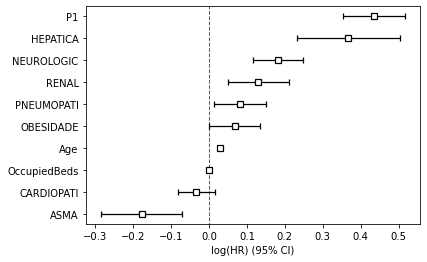

```python
CoxAnalysis(df_gaucho[Hosp & SRAG_COVID], 'Hosp_to_Evolucao','Death', covariates_rs, 28, 0.05)
```

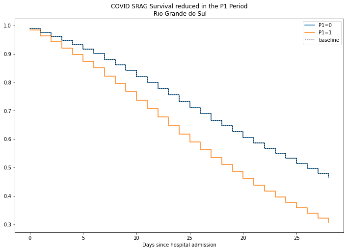

```python
cph.plot_partial_effects_on_outcome(covariates='P1', values=[0,1], title='COVID SRAG Survival reduced in the P1 Period\n Rio Grande do Sul',figsize=(12,8))
plt.xlabel('Days since hospital admission')
plt.show()
```

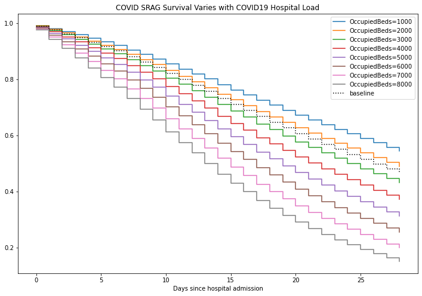

```python
cph.plot_partial_effects_on_outcome(covariates='OccupiedBeds', values=[1000,2000,3000,4000,5000,6000,7000,8000], title='COVID SRAG Survival Varies with COVID19 Hospital Load', figsize=(12,8))
plt.xlabel('Days since hospital admission')
plt.legend(loc='upper right')
plt.show()
```